# Problem Statement

###### Checking income and loan distribution

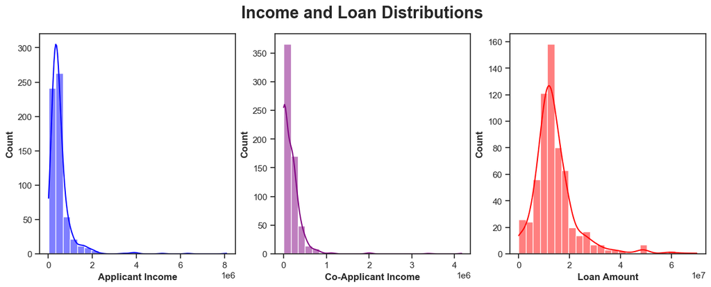

```python
import matplotlib.pyplot as plt
import seaborn as sns

fig, ax = plt.subplots(1, 3, figsize=(15, 5))
fig.suptitle('Income and Loan Distributions', fontweight='heavy', size='xx-large')

variables = ['Applicant_Income', 'Coapplicant_Income', 'Loan_Amount']
colors = ['blue', 'purple', 'red']
labels = ['Applicant Income', 'Co-Applicant Income', 'Loan Amount']

for i in range(3):
    sns.histplot(ax=ax[i], data=df_train, x=variables[i], kde=True, color=colors[i], bins=25)

    ax[i].set_xlabel(labels[i], fontweight='bold')
    ax[i].set_ylabel('Count', fontweight='bold')

plt.show()


#The x-axis labels for each subplot are set to 'Applicant Income', 'Co-Applicant Income', and 'Loan Amount' using the set_xlabel function.
#The y-axis labels for all subplots are set to 'Count' using the set_ylabel function.
```

###### Results

- The Applicant Income, Co-Applicant Income and Loan Amount Features are Highly Right Skewed.
- The distribution of Applicant_income, Co_Applicant Income, and Loan_Amount are positively skewed and contains outliers.
- The distribution of Loan_Amount Term is negativly skewed and contain outliers as well.

###### Understanding Outlier with Box Plot

```python
# https://www.youtube.com/watch?v=sytBDWefYb0
```

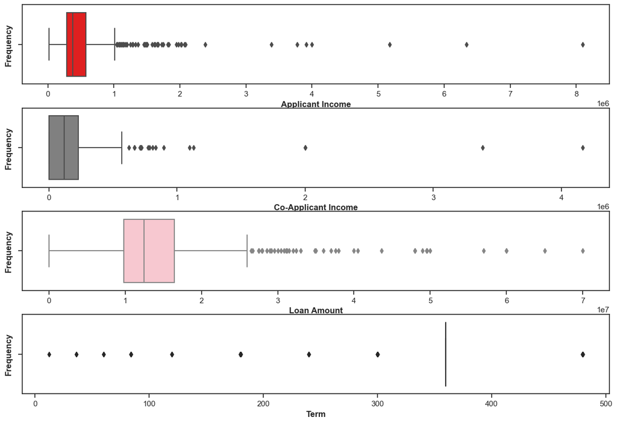

```python
fig, axes = plt.subplots(4, 1, figsize=(15, 10))
plt.subplots_adjust(hspace=0.3)

variables =  ['Applicant_Income', 'Coapplicant_Income', 'Loan_Amount','Term']
colors = ['red', 'gray', 'pink','green']
titles = ['Applicant Income', 'Co-Applicant Income', 'Loan Amount','Term']


for ax, var, color, title in zip(axes, variables, colors, titles):
    sns.boxplot(ax=ax, data=df_train, x=var, color=color)
    ax.set_xlabel(title, fontweight='bold')
    ax.set_ylabel('Frequency', fontweight='bold')

plt.show()
```

```python
# df_train['Applicant_Income'].
```

```python
#Note the outliers min -max value range is as follow
#Applicant income- 0 to 1 -->approx 1000000  as 1e6
#Co -Applicant-0 to 0.5 ---->500000
#Loan Amount- 0 to 3 --->30000000
#Term - 240 to 360--->360
```

###### Noe:

There are many outliers from the Applicant Income, Co-Applicant Income and Loan Amount feature. This might affect later in creating a machine learning to predict loan approval.

###### Checking Correlation of Applicant Income and Co Applicant Income

# Numeric v/s Numeric variable

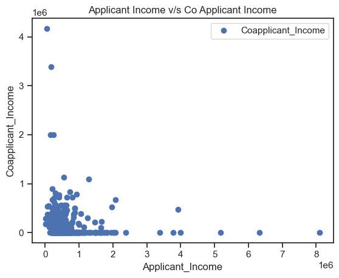

```
Pearson correlation: -0.11660458122889975
```

```python
df_train.plot(x = 'Applicant_Income', y = 'Coapplicant_Income', style = 'o')
plt.title('Applicant Income v/s Co Applicant Income')
plt.xlabel('Applicant_Income')
plt.ylabel('Coapplicant_Income')
plt.show()
print('Pearson correlation:', df_train['Applicant_Income'].corr(df_train['Coapplicant_Income']))
```

###### Data Preprocessing

- Handling Null Values:

Implementing appropriate strategies to handle missing values in your dataset, such as filling them with a specific value, using statistical measures like mean or median, or employing advanced imputation techniques.

- Handle Duplicates:

Identifying and remove any duplicate records from your dataset to avoid redundancy and potential bias in your analysis.

- Encode Categorical Features:

Converting categorical variables into numerical representations suitable for machine learning algorithms. Common encoding techniques include one-hot encoding, label encoding, or ordinal encoding.

- Remove Outliers:

Detecting and remove outliers from your dataset. Outliers can adversely impact the model's performance by distorting the distribution and influencing the decision boundaries. Various statistical methods or domain knowledge can be used to identify outliers.

- Spliting the Dataset:

Spliting the dataset into training and testing sets before performing any further steps. This separation ensures that your model's performance evaluation is done on unseen data, preventing any data leakage and providing a more accurate assessment of its generalization.

- Scaling Numerical Features:

Applying feature scaling techniques to normalize the numerical variables in your dataset. Common scaling methods include standardization (subtracting the mean and dividing by the standard deviation) or normalization (scaling values between a specified range, such as 0 and 1). Note that scaling should be performed separately on the training and testing sets.

###### Dropping Missing Values

```python
print(df_train.shape)
df_train.head()
```

```
(614, 12)
```

|  | Gender | Married | Dependents | Education | Self_Employed | Applicant_Income | Coapplicant_Income | Loan_Amount | Term | Credit_History | Area | Status |
| --- | --- | --- | --- | --- | --- | --- | --- | --- | --- | --- | --- | --- |
| 0 | Male | No | 0 | Graduate | No | 584900 | 0.0 | 15000000 | 360.0 | 1.0 | Urban | Y |
| 1 | Male | Yes | 1 | Graduate | No | 458300 | 150800.0 | 12800000 | 360.0 | 1.0 | Rural | N |
| 2 | Male | Yes | 0 | Graduate | Yes | 300000 | 0.0 | 6600000 | 360.0 | 1.0 | Urban | Y |
| 3 | Male | Yes | 0 | Not Graduate | No | 258300 | 235800.0 | 12000000 | 360.0 | 1.0 | Urban | Y |
| 4 | Male | No | 0 | Graduate | No | 600000 | 0.0 | 14100000 | 360.0 | 1.0 | Urban | Y |

```python
# checking the null percentage
(df_train.isna().sum()/len(df_train)*100).sort_values(ascending=False)
```

```
Credit_History        8.143322
Self_Employed         5.211726
Dependents            2.442997
Term                  2.280130
Gender                2.117264
Married               0.488599
Education             0.000000
Applicant_Income      0.000000
Coapplicant_Income    0.000000
Loan_Amount           0.000000
Area                  0.000000
Status                0.000000
dtype: float64
```

```python
# null percentage of test
(df_test.isna().sum()/len(df_train)*100).sort_values(ascending=False)
```

```
Credit_History        4.723127
Self_Employed         3.745928
Gender                1.791531
Dependents            1.628664
Term                  0.977199
Married               0.000000
Education             0.000000
Applicant_Income      0.000000
Coapplicant_Income    0.000000
Loan_Amount           0.000000
Area                  0.000000
dtype: float64
```

```python
df_train.Credit_History.value_counts()
```

```
1.0    475
0.0     89
Name: Credit_History, dtype: int64
```

```python
df_train.Gender.value_counts()
```

```
Male      489
Female    112
Name: Gender, dtype: int64
```

```python
df_train.Married.value_counts()
```

```
Yes    398
No     213
Name: Married, dtype: int64
```

```python
# Splitting the dataset into train and test set before data cleaning to avoid data leakage.
# Instead of using train_test_split, we have used pandas sample method to split the dataset into train and validation set. Achieves the same result.
df_val = df_train.sample(frac = 0.15)
df_train = df_train.drop(df_val.index)
```

```python
# Filling missing values so that we don't lose much data
```

```python
df_train['Credit_History'].fillna(0, inplace=True)
df_test['Credit_History'].fillna(0, inplace=True)
df_val['Credit_History'].fillna(0, inplace=True)

df_train['Self_Employed'].fillna('No', inplace=True)
df_test['Self_Employed'].fillna('No', inplace=True)
df_val['Self_Employed'].fillna('No', inplace=True)

df_train['Gender'].fillna('Male', inplace=True)
df_test['Gender'].fillna('Male', inplace=True)
df_val['Gender'].fillna('Male', inplace=True)

df_train['Dependents'].fillna('0', inplace=True)
df_test['Dependents'].fillna('0', inplace=True)
df_val['Dependents'].fillna('0', inplace=True)

df_train['Loan_Amount'].fillna(df_train['Loan_Amount'].mean(), inplace=True)
# filling missing values using train average
df_test['Loan_Amount'].fillna(df_train['Loan_Amount'].mean(), inplace=True)
df_val['Loan_Amount'].fillna(df_train['Loan_Amount'].mean(), inplace=True)

df_train['Term'].fillna(df_train['Term'].mean(), inplace=True)
# filling missing values using train average
df_test['Term'].fillna(df_train['Term'].mean(), inplace=True)
df_val['Term'].fillna(df_train['Term'].mean(), inplace=True)

df_train['Married'].fillna('Yes', inplace=True)
df_test['Married'].fillna('Yes', inplace=True)
df_val['Married'].fillna('Yes', inplace=True)
```

```python
df_train = df_train.dropna().reset_index(drop=True)
df_val = df_val.dropna().reset_index(drop=True)

# We can't drop the rows with missing values from the test set as we need to make predictions on it and submit it on Kaggle.
# So we will fill the missing values in the test set with the mode of the respective columns in the train set.
df_test = df_test.fillna(df_train.mode().iloc[0]).reset_index(drop=True)
#the code removes any rows with null values from the DataFrame df_train and resets the index, resulting in a modified DataFrame with continuous indices.
#The modified DataFrame is then assigned back to the variable df_train
```

```python
df_train.isna().sum()
#Note there are no null values now
```

```
Gender                0
Married               0
Dependents            0
Education             0
Self_Employed         0
Applicant_Income      0
Coapplicant_Income    0
Loan_Amount           0
Term                  0
Credit_History        0
Area                  0
Status                0
dtype: int64
```

###### Removing duplicates

```python
df_train = df_train.drop_duplicates().reset_index(drop=True)
df_val = df_val.drop_duplicates().reset_index(drop=True)
df_train.shape
```

```
(522, 12)
```

###### Outliers Removal

There are multiple ways to remove outliers from a dataset. Here are a few common approaches: The detail explanation can be found in below video https://youtu.be/XzEXB12N1xs

- 1- Z-Score Method: Calculate the z-score for each data point, which represents how many standard deviations it is away from the mean. Define a threshold (e.g., z-score > 3 or z-score < -3) and remove the data points that exceed this threshold.
- 2- IQR (Interquartile Range) Method: Calculate the IQR, which is the range between the 25th and 75th percentiles of the data. Define a threshold (e.g., values outside 1.5 times the IQR) and remove the data points that fall outside this range.
- 3-Visual Inspection: Create box plots, histograms, or scatter plots to visualize the data distribution. Identify any data points that appear to be significantly distant from the majority of the data and remove them based on domain knowledge or data-specific criteria.
- 4-Domain Knowledge: Apply domain-specific rules or knowledge to identify and remove outliers. For example, if we know the valid range of values for a particular feature, you can remove any data points that fall outside that range.

It's important to note that the choice of outlier removal method depends on your dataset, the specific problem domain, and the characteristics of the outliers you are dealing with. It's advisable to exercise caution and consider the implications of removing outliers, as it can potentially affect the overall distribution and statistical properties of the data.

###### 1:Z-Score

Z-scores can determine how odd observation is when your data follow a normal distribution. Z-scores are the number of standard deviations above and below the mean decrease for each value. For example, a Z-score of 2 indicates that the observation is two standard deviations above the mean, while a Z-score of -2 indicates two standard deviations below the mean. The Z score of zero represents a value equal to the mean. To calculate the Z-score for the observation, take the original measurement, subtract the mean, and divide by the standard deviation. Mathematically, the formula for this process is: z = (X – μ) / σ

```python
#Note:The sections below have  been commented ,uncomment it for running
```

```python
#Our data shape
df_train.shape
```

```
(522, 12)
```

```python
#Removing outlier for Loan_Amount and checking shape of data set
# from scipy import stats
# z = stats.zscore(df_train['Loan_Amount'])

# # Identify the outliers that have a Z-score greater than 3
# outliers = (z > 3) | (z < -3)

# # Remove the outliers from the DataFrame
# df_train = df_train[~outliers]
# df_train.shape
```

```python
#Removing outliers for the Applicant_Income
# z = stats.zscore(df_train['Applicant_Income'])
# outliers = (z > 3) | (z < -3)
# df_train = df_train[~outliers]
# df_train.shape
```

```python
#Removing outliers for the Loan_Amount
# z = stats.zscore(df_train['Coapplicant_Income'])
# outliers = (z > 3) | (z < -3)
# df_train = df_train[~outliers]
# df_train.shape
```

```python
#Removing outliers for the Term
# z = stats.zscore(df_train['Term'])
# outliers = (z > 3) | (z < -3)
# df_train = df_train[~outliers]
# df_train.shape
```

###### 2:Using IQR

```python
#Uncomment it for execution
```

###### Step by Step detail Code

```python
# import seaborn as sns
# # Specify the column names and the DataFrame
# x_column = "Status"
# y_column = "Applicant_Income"
# data = df_train

# # Set the color palette
# palette = 'crest'

# # Create the box plot
# sns.boxplot(x=x_column, y=y_column, data=data, palette=palette)

# #We can observe that there are lots of outliers in Applicant Income, and the distribution also positively skewed.
```

```python
# #Creating a copy of the DataFrame
# df1 = df_train.copy()
# #Creating Limits for applicant_income column

# q1_ap_inc = df1['Applicant_Income'].quantile(0.25)
# q3_ap_inc = df1['Applicant_Income'].quantile(0.75)

# iqr_ap_inc = q3_ap_inc - q1_ap_inc

# lower_limit_ap_inc = q1_ap_inc - 1.5*iqr_ap_inc
# upper_limit_ap_inc = q3_ap_inc + 1.5*iqr_ap_inc
```

```python
# sns.boxplot(x = "Status", y = "Coapplicant_Income", data = data, palette="crest");
#It's clear that Co Applicant Income has a number of outliers, and the distribution is also positively skewed.
```

```python
# #Creating Limits for coapplicant_income column

# q1_coap_inc = df1['Coapplicant_Income'].quantile(0.25)
# q3_coap_inc = df1['Coapplicant_Income'].quantile(0.75)

# iqr_coap_inc = q3_coap_inc - q1_coap_inc

# lower_limit_coap_inc = q1_coap_inc - 1.5*iqr_coap_inc
# upper_limit_coap_inc = q3_coap_inc + 1.5*iqr_coap_inc
```

```python
# sns.boxplot(x = "Status", y = "Loan_Amount", data = data, palette = "crest");
```

```python
# #Creating Limits for loan_amount column

# q1_loan = df1['Loan_Amount'].quantile(0.25)
# q3_loan = df1['Loan_Amount'].quantile(0.75)

# iqr_loan = q3_loan - q1_loan

# lower_limit_loan = q1_loan - 1.5*iqr_loan
# upper_limit_loan = q3_loan + 1.5*iqr_loan
```

```python
# #Applying Limits into the new Data Frame

# df1 = df1[(df1.Applicant_Income > lower_limit_ap_inc) & (df1.Applicant_Income< upper_limit_ap_inc)]

# df1 = df1[(df1.Coapplicant_Income > lower_limit_coap_inc) & (df1.Coapplicant_Income< upper_limit_coap_inc)]

# df1 =df1[(df1.Loan_Amount > lower_limit_loan) & (df1.Loan_Amount< upper_limit_loan)]
# df1.shape
```

###### Simplified code

```python
#Simplified code
# specify the columns to remove outliers from dataframe
column_names = ['Applicant_Income', 'Coapplicant_Income', 'Loan_Amount','Term']

# remove outliers for each selected column using the IQR method
for column_name in column_names:
    Q1 = df_train[column_name].quantile(0.25)
    Q3 = df_train[column_name].quantile(0.75)
    IQR = Q3 - Q1
    df_train = df_train[~((df_train[column_name] < (Q1 - 1.5 * IQR)) | (df_train[column_name] > (Q3 + 1.5 * IQR)))]

df_train.shape
```

```
(354, 12)
```

###### 3:Visual Inspection

```python
# # As analysed above in the numerical features outliers range we can eliminate them by following
# df_new=df_train.copy()
# df_train_new = df_new[(df_new['Applicant_Income'] < 1000000) &
#                     (df_new['Coapplicant_Income'] < 500000) &
#                     (df_new['Loan_Amount'] < 30000000) &
#                     (df_new['Term'] > 240)].reset_index(drop=True)
# df_train_new.shape
```

#### Encoding Categorical Features

https://www.statology.org/label-encoding-in-python/

```python
# Label Encoding for Object datatype
# Loop over each column in the DataFrame where dtype is 'object'
for col in df_train.select_dtypes(include=['object']).columns:

    # Print the column name and the unique values
    print(f"{col}: {df_train[col].unique()}")
```

```
Gender: ['Male' 'Female']
Married: ['No' 'Yes']
Dependents: ['0' '1' '3+' '2']
Education: ['Graduate' 'Not Graduate']
Self_Employed: ['No' 'Yes']
Area: ['Urban' 'Rural' 'Semiurban']
Status: ['Y' 'N']
```

```python
# df_train[['Term', 'Credit_History']] = df_train[['Term', 'Credit_History']].astype(str)
```

###### Performing encoding Label Encoding

Label Encoding means converting categorical features into numerical values.

https://thatascience.com/learn-machine-learning/label-encoding/

```python
from sklearn import preprocessing

# Loop over each column in the DataFrame where dtype is 'object'
for col in df_train.select_dtypes(include=['object']).columns:

    # Initialize a LabelEncoder object
    label_encoder = preprocessing.LabelEncoder()

    # Fit the encoder to the unique values in the column
    label_encoder.fit(df_train[col].unique())

    # Transform the column using the encoder
    df_train[col] = label_encoder.transform(df_train[col])
    if col != 'Status':
        # Transform the column using the encoder in the test set
        df_test[col] = label_encoder.transform(df_test[col])
    # Transform the column using the encoder in the validation set
    df_val[col] = label_encoder.transform(df_val[col])

    # Print the column name and the unique encoded values
    print(f"{col}: {df_train[col].unique()}")
```

```
Gender: [1 0]
Married: [0 1]
Dependents: [0 1 3 2]
Education: [0 1]
Self_Employed: [0 1]
Area: [2 0 1]
Status: [1 0]
```

```python
# sns.countplot(df_train['Status'])
# df_train['Status'].value_counts()
```

###### Evaluating the Model

we can evaluate the model in addition to the accuracy score We'll evaluate the model using below metrics in addition to the accuracy score:

- 1-Confusion Matrix https://www.youtube.com/watch?v=_CGTbkHwUHQ
- 2-AUC ROC CURVE https://www.youtube.com/watch?v=6CrhEbU3XHo

```python
#The above will be implemented below
```

### Model Implementation

```python
x_train = df_train.drop('Status', axis=1)
y_train = df_train['Status']

x_val = df_val.drop('Status', axis=1)
y_val = df_val['Status']

# x_test = df_test.drop('Status', axis=1)
x_test = df_test
```

```python
print(df_train.isnull().sum().sum())
print(df_val.isnull().sum().sum())
print(df_test.isnull().sum().sum())
```

```
0
0
0
```

```python
# Splitting the Dataset
# X_train, X_test, y_train, y_test = train_test_split(x, y, test_size=0.2, random_state=101, shuffle=True)

# print('Shape of training set:', X_train.shape)
# print('Shape of test set:', X_test.shape)
```

[output not shown]

###### Decision Tree without Hyperparameter Tuning

```python
clf = DecisionTreeClassifier()

# Train the classifier on the training data
clf.fit(x_train, y_train)

# Make predictions on the testing data
y_pred = clf.predict(x_val)

# Calculate the accuracy of the model
accuracy = accuracy_score(y_val, y_pred)
print("Accuracy Score :", round(accuracy_score(y_val, y_pred)*100 ,2), "%")
print("Accuracy:", accuracy)
```

```
Accuracy Score : 68.48 %
Accuracy: 0.6847826086956522
```

```python
#Checking Confusion matrix and AUC ROC Curve
```

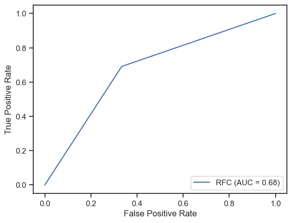

```python
fpr, tpr, thresholds = roc_curve(y_val, y_pred)
roc_auc = auc(fpr, tpr)
display = RocCurveDisplay(fpr=fpr, tpr=tpr, roc_auc=roc_auc, estimator_name='RFC')
display.plot()
plt.show()
```

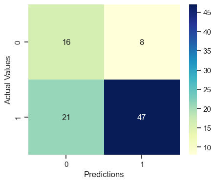

```python
#Confusion matrix
# Display the confusion matrix
import seaborn as sb
cm = confusion_matrix(y_val, y_pred)
cm_df = pd.DataFrame(cm)

plt.figure(figsize=(5,4))
sb.heatmap(cm_df, annot=True, fmt='d', cmap='YlGnBu')
plt.xlabel('Predictions', fontsize=12)
plt.ylabel('Actual Values', fontsize=12)
plt.show()
```